# Risk Factor Analysis

## Outcome Variable

**Outcome Variable:** wasted

## Predictor Variables

**Intervention Variable:** hdlvry

**Adjustment Set:**

unadjusted

## Stratifying Variables

The analysis was stratified on these variable(s):

- agecat
- studyid
- country

## Data Summary

| agecat | studyid | country | hdlvry | wasted | n_cell | n |
| --- | --- | --- | --- | --- | --- | --- |
| Birth | ki1000108-CMC-V-BCS-2002 | INDIA | 0 | 0 | 74 | 88 |
| Birth | ki1000108-CMC-V-BCS-2002 | INDIA | 0 | 1 | 12 | 88 |
| Birth | ki1000108-CMC-V-BCS-2002 | INDIA | 1 | 0 | 0 | 88 |
| Birth | ki1000108-CMC-V-BCS-2002 | INDIA | 1 | 1 | 2 | 88 |
| Birth | ki1000108-IRC | INDIA | 0 | 0 | 249 | 343 |
| Birth | ki1000108-IRC | INDIA | 0 | 1 | 88 | 343 |
| Birth | ki1000108-IRC | INDIA | 1 | 0 | 2 | 343 |
| Birth | ki1000108-IRC | INDIA | 1 | 1 | 4 | 343 |
| Birth | ki1000109-EE | PAKISTAN | 0 | 0 | 1 | 1 |
| Birth | ki1000109-EE | PAKISTAN | 0 | 1 | 0 | 1 |
| Birth | ki1000109-EE | PAKISTAN | 1 | 0 | 0 | 1 |
| Birth | ki1000109-EE | PAKISTAN | 1 | 1 | 0 | 1 |
| Birth | ki1000304b-SAS-CompFeed | INDIA | 0 | 0 | 5 | 160 |
| Birth | ki1000304b-SAS-CompFeed | INDIA | 0 | 1 | 1 | 160 |
| Birth | ki1000304b-SAS-CompFeed | INDIA | 1 | 0 | 144 | 160 |
| Birth | ki1000304b-SAS-CompFeed | INDIA | 1 | 1 | 10 | 160 |
| Birth | ki1017093c-NIH-Crypto | BANGLADESH | 0 | 0 | 16 | 23 |
| Birth | ki1017093c-NIH-Crypto | BANGLADESH | 0 | 1 | 3 | 23 |
| Birth | ki1017093c-NIH-Crypto | BANGLADESH | 1 | 0 | 4 | 23 |
| Birth | ki1017093c-NIH-Crypto | BANGLADESH | 1 | 1 | 0 | 23 |
| Birth | ki1135781-COHORTS | INDIA | 0 | 0 | 2284 | 4389 |
| Birth | ki1135781-COHORTS | INDIA | 0 | 1 | 479 | 4389 |
| Birth | ki1135781-COHORTS | INDIA | 1 | 0 | 1344 | 4389 |
| Birth | ki1135781-COHORTS | INDIA | 1 | 1 | 282 | 4389 |
| Birth | kiGH5241-JiVitA-3 | BANGLADESH | 0 | 0 | 8 | 263 |
| Birth | kiGH5241-JiVitA-3 | BANGLADESH | 0 | 1 | 0 | 263 |
| Birth | kiGH5241-JiVitA-3 | BANGLADESH | 1 | 0 | 226 | 263 |
| Birth | kiGH5241-JiVitA-3 | BANGLADESH | 1 | 1 | 29 | 263 |
| Birth | kiGH5241-JiVitA-4 | BANGLADESH | 0 | 0 | 41 | 681 |
| Birth | kiGH5241-JiVitA-4 | BANGLADESH | 0 | 1 | 2 | 681 |

[output cut: 86 more lines]

The following strata were considered:

- agecat: 24 months, studyid: ki1000108-CMC-V-BCS-2002, country: INDIA
- agecat: 24 months, studyid: ki1000108-IRC, country: INDIA
- agecat: 24 months, studyid: ki1017093b-PROVIDE, country: BANGLADESH
- agecat: 24 months, studyid: ki1017093c-NIH-Crypto, country: BANGLADESH
- agecat: 24 months, studyid: ki1066203-TanzaniaChild2, country: TANZANIA, UNITED REPUBLIC OF
- agecat: 24 months, studyid: ki1113344-GMS-Nepal, country: NEPAL
- agecat: 24 months, studyid: ki1135781-COHORTS, country: INDIA
- agecat: 24 months, studyid: kiGH5241-JiVitA-3, country: BANGLADESH
- agecat: 24 months, studyid: kiGH5241-JiVitA-4, country: BANGLADESH
- agecat: 6 months, studyid: ki1000108-CMC-V-BCS-2002, country: INDIA
- agecat: 6 months, studyid: ki1000108-IRC, country: INDIA
- agecat: 6 months, studyid: ki1000109-EE, country: PAKISTAN
- agecat: 6 months, studyid: ki1000304b-SAS-CompFeed, country: INDIA
- agecat: 6 months, studyid: ki1000304b-SAS-FoodSuppl, country: INDIA
- agecat: 6 months, studyid: ki1017093b-PROVIDE, country: BANGLADESH
- agecat: 6 months, studyid: ki1017093c-NIH-Crypto, country: BANGLADESH
- agecat: 6 months, studyid: ki1066203-TanzaniaChild2, country: TANZANIA, UNITED REPUBLIC OF
- agecat: 6 months, studyid: ki1113344-GMS-Nepal, country: NEPAL
- agecat: 6 months, studyid: ki1135781-COHORTS, country: INDIA
- agecat: 6 months, studyid: kiGH5241-JiVitA-3, country: BANGLADESH
- agecat: 6 months, studyid: kiGH5241-JiVitA-4, country: BANGLADESH
- agecat: Birth, studyid: ki1000108-CMC-V-BCS-2002, country: INDIA
- agecat: Birth, studyid: ki1000108-IRC, country: INDIA
- agecat: Birth, studyid: ki1000109-EE, country: PAKISTAN
- agecat: Birth, studyid: ki1000304b-SAS-CompFeed, country: INDIA
- agecat: Birth, studyid: ki1017093c-NIH-Crypto, country: BANGLADESH
- agecat: Birth, studyid: ki1135781-COHORTS, country: INDIA
- agecat: Birth, studyid: kiGH5241-JiVitA-3, country: BANGLADESH
- agecat: Birth, studyid: kiGH5241-JiVitA-4, country: BANGLADESH

### Dropped Strata

Some strata were dropped due to rare outcomes:

- agecat: Birth, studyid: ki1000108-CMC-V-BCS-2002, country: INDIA
- agecat: Birth, studyid: ki1000108-IRC, country: INDIA
- agecat: Birth, studyid: ki1000109-EE, country: PAKISTAN
- agecat: Birth, studyid: ki1000304b-SAS-CompFeed, country: INDIA
- agecat: Birth, studyid: ki1017093c-NIH-Crypto, country: BANGLADESH
- agecat: Birth, studyid: kiGH5241-JiVitA-3, country: BANGLADESH
- agecat: Birth, studyid: kiGH5241-JiVitA-4, country: BANGLADESH
- agecat: 6 months, studyid: ki1000108-CMC-V-BCS-2002, country: INDIA
- agecat: 6 months, studyid: ki1000108-IRC, country: INDIA
- agecat: 6 months, studyid: ki1017093b-PROVIDE, country: BANGLADESH
- agecat: 6 months, studyid: ki1066203-TanzaniaChild2, country: TANZANIA, UNITED REPUBLIC OF
- agecat: 6 months, studyid: kiGH5241-JiVitA-3, country: BANGLADESH
- agecat: 24 months, studyid: ki1000108-CMC-V-BCS-2002, country: INDIA
- agecat: 24 months, studyid: ki1000108-IRC, country: INDIA
- agecat: 24 months, studyid: ki1066203-TanzaniaChild2, country: TANZANIA, UNITED REPUBLIC OF

## Methods Detail

We’re interested in the causal parameters $E[Y_a]$ for all values of $a \in \mathcal{A}$. These parameters represent the mean outcome if, possibly contrary to fact, we intervened to set all units to have $A=a$. Under the randomization and positivity assumptions, these are identified by the statistical parameters $\psi_a=E_W[E_{Y|A,W}(Y|A=a,W)]$. In addition, we’re interested in the mean of $Y$, $E[Y]$ under no intervention (the observed mean). We will estimate these parameters by using SuperLearner to fit the relevant likelihood factors – $E_{Y|A,W}(Y|A=a,W)$ and $p(A=a|W)$, and then updating our likelihood fit using a joint TMLE.

For unadjusted analyses ($W=\{\}$), initial likelihoods were estimated using Lrnr_glm to estimate the simple $E(Y|A)$ and Lrnr_mean to estimate $p(A)$. For adjusted analyses, a small library containing Lrnr_glmnet, Lrnr_xgboost, and Lrnr_mean was used.

Having estimated these parameters, we will then use the delta method to estimate relative risks and attributable risks relative to a prespecified baseline level of $A$.

# Results Detail

## Results Plots

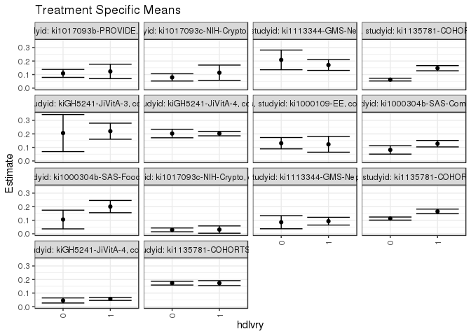

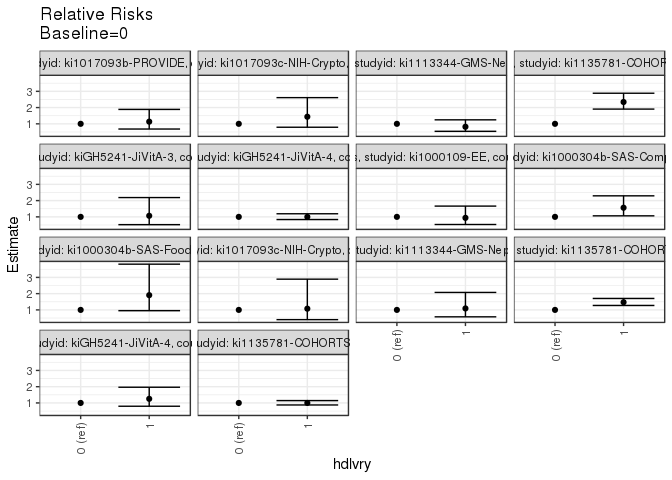

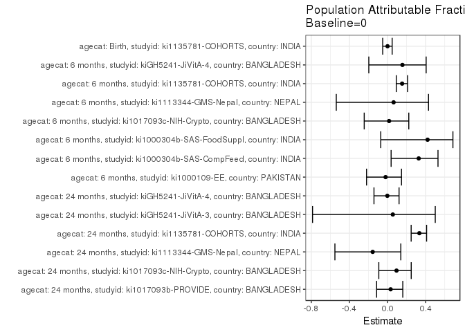

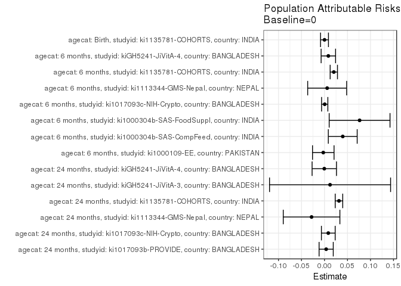

## Results Table

### Parameter: TSM

| agecat | studyid | country | intervention_level | baseline_level | estimate | ci_lower | ci_upper |
| --- | --- | --- | --- | --- | --- | --- | --- |
| Birth | ki1135781-COHORTS | INDIA | 0 | NA | 0.1733623 | 0.1592453 | 0.1874793 |
| Birth | ki1135781-COHORTS | INDIA | 1 | NA | 0.1734317 | 0.1550265 | 0.1918370 |
| 6 months | ki1000109-EE | PAKISTAN | 0 | NA | 0.1309524 | 0.0892455 | 0.1726593 |
| 6 months | ki1000109-EE | PAKISTAN | 1 | NA | 0.1229508 | 0.0646026 | 0.1812990 |
| 6 months | ki1000304b-SAS-CompFeed | INDIA | 0 | NA | 0.0816327 | 0.0505071 | 0.1127582 |
| 6 months | ki1000304b-SAS-CompFeed | INDIA | 1 | NA | 0.1275239 | 0.1035834 | 0.1514644 |
| 6 months | ki1000304b-SAS-FoodSuppl | INDIA | 0 | NA | 0.1052632 | 0.0361757 | 0.1743506 |
| 6 months | ki1000304b-SAS-FoodSuppl | INDIA | 1 | NA | 0.2006579 | 0.1555785 | 0.2457373 |
| 6 months | ki1017093c-NIH-Crypto | BANGLADESH | 0 | NA | 0.0288809 | 0.0149256 | 0.0428361 |
| 6 months | ki1017093c-NIH-Crypto | BANGLADESH | 1 | NA | 0.0310559 | 0.0042420 | 0.0578698 |
| 6 months | ki1113344-GMS-Nepal | NEPAL | 0 | NA | 0.0852713 | 0.0370307 | 0.1335120 |
| 6 months | ki1113344-GMS-Nepal | NEPAL | 1 | NA | 0.0929648 | 0.0644093 | 0.1215204 |
| 6 months | ki1135781-COHORTS | INDIA | 0 | NA | 0.1122238 | 0.1007266 | 0.1237209 |
| 6 months | ki1135781-COHORTS | INDIA | 1 | NA | 0.1651835 | 0.1480172 | 0.1823499 |
| 6 months | kiGH5241-JiVitA-4 | BANGLADESH | 0 | NA | 0.0452865 | 0.0265403 | 0.0640327 |
| 6 months | kiGH5241-JiVitA-4 | BANGLADESH | 1 | NA | 0.0567568 | 0.0457199 | 0.0677936 |
| 24 months | ki1017093b-PROVIDE | BANGLADESH | 0 | NA | 0.1087963 | 0.0794078 | 0.1381848 |
| 24 months | ki1017093b-PROVIDE | BANGLADESH | 1 | NA | 0.1232877 | 0.0699129 | 0.1766624 |
| 24 months | ki1017093c-NIH-Crypto | BANGLADESH | 0 | NA | 0.0792839 | 0.0524775 | 0.1060903 |
| 24 months | ki1017093c-NIH-Crypto | BANGLADESH | 1 | NA | 0.1138211 | 0.0576400 | 0.1700023 |
| 24 months | ki1113344-GMS-Nepal | NEPAL | 0 | NA | 0.2083333 | 0.1355931 | 0.2810735 |
| 24 months | ki1113344-GMS-Nepal | NEPAL | 1 | NA | 0.1705202 | 0.1308498 | 0.2101907 |
| 24 months | ki1135781-COHORTS | INDIA | 0 | NA | 0.0627823 | 0.0526768 | 0.0728878 |
| 24 months | ki1135781-COHORTS | INDIA | 1 | NA | 0.1470811 | 0.1279641 | 0.1661981 |
| 24 months | kiGH5241-JiVitA-3 | BANGLADESH | 0 | NA | 0.2058824 | 0.0691344 | 0.3426304 |
| 24 months | kiGH5241-JiVitA-3 | BANGLADESH | 1 | NA | 0.2196078 | 0.1605007 | 0.2787149 |
| 24 months | kiGH5241-JiVitA-4 | BANGLADESH | 0 | NA | 0.2025194 | 0.1710521 | 0.2339867 |
| 24 months | kiGH5241-JiVitA-4 | BANGLADESH | 1 | NA | 0.2019588 | 0.1854227 | 0.2184949 |

### Parameter: E(Y)

| agecat | studyid | country | intervention_level | baseline_level | estimate | ci_lower | ci_upper |
| --- | --- | --- | --- | --- | --- | --- | --- |
| Birth | ki1135781-COHORTS | INDIA | NA | NA | 0.1733880 | 0.1621865 | 0.1845895 |
| 6 months | ki1000109-EE | PAKISTAN | NA | NA | 0.1283422 | 0.0943991 | 0.1622853 |
| 6 months | ki1000304b-SAS-CompFeed | INDIA | NA | NA | 0.1213235 | 0.0974115 | 0.1452356 |
| 6 months | ki1000304b-SAS-FoodSuppl | INDIA | NA | NA | 0.1815789 | 0.1427684 | 0.2203895 |
| 6 months | ki1017093c-NIH-Crypto | BANGLADESH | NA | NA | 0.0293706 | 0.0169860 | 0.0417552 |
| 6 months | ki1113344-GMS-Nepal | NEPAL | NA | NA | 0.0910816 | 0.0664930 | 0.1156701 |
| 6 months | ki1135781-COHORTS | INDIA | NA | NA | 0.1325096 | 0.1228094 | 0.1422097 |
| 6 months | kiGH5241-JiVitA-4 | BANGLADESH | NA | NA | 0.0536863 | 0.0440214 | 0.0633512 |
| 24 months | ki1017093b-PROVIDE | BANGLADESH | NA | NA | 0.1124567 | 0.0866788 | 0.1382347 |
| 24 months | ki1017093c-NIH-Crypto | BANGLADESH | NA | NA | 0.0875486 | 0.0630907 | 0.1120065 |
| 24 months | ki1113344-GMS-Nepal | NEPAL | NA | NA | 0.1802575 | 0.1453188 | 0.2151962 |
| 24 months | ki1135781-COHORTS | INDIA | NA | NA | 0.0942542 | 0.0846183 | 0.1038901 |
| 24 months | kiGH5241-JiVitA-3 | BANGLADESH | NA | NA | 0.2179931 | 0.1635507 | 0.2724354 |
| 24 months | kiGH5241-JiVitA-4 | BANGLADESH | NA | NA | 0.2021037 | 0.1874836 | 0.2167238 |

### Parameter: RR

| agecat | studyid | country | intervention_level | baseline_level | estimate | ci_lower | ci_upper |
| --- | --- | --- | --- | --- | --- | --- | --- |
| Birth | ki1135781-COHORTS | INDIA | 0 | 0 | 1.0000000 | 1.0000000 | 1.000000 |
| Birth | ki1135781-COHORTS | INDIA | 1 | 0 | 1.0004006 | 0.8751457 | 1.143582 |
| 6 months | ki1000109-EE | PAKISTAN | 0 | 0 | 1.0000000 | 1.0000000 | 1.000000 |
| 6 months | ki1000109-EE | PAKISTAN | 1 | 0 | 0.9388972 | 0.5301581 | 1.662764 |
| 6 months | ki1000304b-SAS-CompFeed | INDIA | 0 | 0 | 1.0000000 | 1.0000000 | 1.000000 |
| 6 months | ki1000304b-SAS-CompFeed | INDIA | 1 | 0 | 1.5621679 | 1.0634896 | 2.294680 |
| 6 months | ki1000304b-SAS-FoodSuppl | INDIA | 0 | 0 | 1.0000000 | 1.0000000 | 1.000000 |
| 6 months | ki1000304b-SAS-FoodSuppl | INDIA | 1 | 0 | 1.9062500 | 0.9525832 | 3.814668 |
| 6 months | ki1017093c-NIH-Crypto | BANGLADESH | 0 | 0 | 1.0000000 | 1.0000000 | 1.000000 |
| 6 months | ki1017093c-NIH-Crypto | BANGLADESH | 1 | 0 | 1.0753106 | 0.3997909 | 2.892244 |
| 6 months | ki1113344-GMS-Nepal | NEPAL | 0 | 0 | 1.0000000 | 1.0000000 | 1.000000 |
| 6 months | ki1113344-GMS-Nepal | NEPAL | 1 | 0 | 1.0902238 | 0.5727202 | 2.075338 |
| 6 months | ki1135781-COHORTS | INDIA | 0 | 0 | 1.0000000 | 1.0000000 | 1.000000 |
| 6 months | ki1135781-COHORTS | INDIA | 1 | 0 | 1.4719124 | 1.2720532 | 1.703172 |
| 6 months | kiGH5241-JiVitA-4 | BANGLADESH | 0 | 0 | 1.0000000 | 1.0000000 | 1.000000 |
| 6 months | kiGH5241-JiVitA-4 | BANGLADESH | 1 | 0 | 1.2532818 | 0.7984110 | 1.967302 |
| 24 months | ki1017093b-PROVIDE | BANGLADESH | 0 | 0 | 1.0000000 | 1.0000000 | 1.000000 |
| 24 months | ki1017093b-PROVIDE | BANGLADESH | 1 | 0 | 1.1331973 | 0.6802836 | 1.887648 |
| 24 months | ki1017093c-NIH-Crypto | BANGLADESH | 0 | 0 | 1.0000000 | 1.0000000 | 1.000000 |
| 24 months | ki1017093c-NIH-Crypto | BANGLADESH | 1 | 0 | 1.4356150 | 0.7892324 | 2.611386 |
| 24 months | ki1113344-GMS-Nepal | NEPAL | 0 | 0 | 1.0000000 | 1.0000000 | 1.000000 |
| 24 months | ki1113344-GMS-Nepal | NEPAL | 1 | 0 | 0.8184971 | 0.5380274 | 1.245174 |
| 24 months | ki1135781-COHORTS | INDIA | 0 | 0 | 1.0000000 | 1.0000000 | 1.000000 |
| 24 months | ki1135781-COHORTS | INDIA | 1 | 0 | 2.3427166 | 1.9048892 | 2.881176 |
| 24 months | kiGH5241-JiVitA-3 | BANGLADESH | 0 | 0 | 1.0000000 | 1.0000000 | 1.000000 |
| 24 months | kiGH5241-JiVitA-3 | BANGLADESH | 1 | 0 | 1.0666667 | 0.5204438 | 2.186168 |
| 24 months | kiGH5241-JiVitA-4 | BANGLADESH | 0 | 0 | 1.0000000 | 1.0000000 | 1.000000 |
| 24 months | kiGH5241-JiVitA-4 | BANGLADESH | 1 | 0 | 0.9972320 | 0.8357664 | 1.189892 |

### Parameter: PAR

| agecat | studyid | country | intervention_level | baseline_level | estimate | ci_lower | ci_upper |
| --- | --- | --- | --- | --- | --- | --- | --- |
| Birth | ki1135781-COHORTS | INDIA | 0 | NA | 0.0000257 | -0.0085676 | 0.0086191 |
| 6 months | ki1000109-EE | PAKISTAN | 0 | NA | -0.0026101 | -0.0260090 | 0.0207887 |
| 6 months | ki1000304b-SAS-CompFeed | INDIA | 0 | NA | 0.0396909 | 0.0083211 | 0.0710606 |
| 6 months | ki1000304b-SAS-FoodSuppl | INDIA | 0 | NA | 0.0763158 | 0.0102090 | 0.1424226 |
| 6 months | ki1017093c-NIH-Crypto | BANGLADESH | 0 | NA | 0.0004898 | -0.0063172 | 0.0072967 |
| 6 months | ki1113344-GMS-Nepal | NEPAL | 0 | NA | 0.0058103 | -0.0365272 | 0.0481478 |
| 6 months | ki1135781-COHORTS | INDIA | 0 | NA | 0.0202858 | 0.0123377 | 0.0282340 |
| 6 months | kiGH5241-JiVitA-4 | BANGLADESH | 0 | NA | 0.0083998 | -0.0072941 | 0.0240937 |
| 24 months | ki1017093b-PROVIDE | BANGLADESH | 0 | NA | 0.0036605 | -0.0117389 | 0.0190598 |
| 24 months | ki1017093c-NIH-Crypto | BANGLADESH | 0 | NA | 0.0082648 | -0.0066858 | 0.0232153 |
| 24 months | ki1113344-GMS-Nepal | NEPAL | 0 | NA | -0.0280758 | -0.0896128 | 0.0334612 |
| 24 months | ki1135781-COHORTS | INDIA | 0 | NA | 0.0314719 | 0.0232878 | 0.0396560 |
| 24 months | kiGH5241-JiVitA-3 | BANGLADESH | 0 | NA | 0.0121107 | -0.1194466 | 0.1436680 |
| 24 months | kiGH5241-JiVitA-4 | BANGLADESH | 0 | NA | -0.0004157 | -0.0269257 | 0.0260943 |

### Parameter: PAF

| agecat | studyid | country | intervention_level | baseline_level | estimate | ci_lower | ci_upper |
| --- | --- | --- | --- | --- | --- | --- | --- |
| Birth | ki1135781-COHORTS | INDIA | 0 | NA | 0.0001484 | -0.0506619 | 0.0485015 |
| 6 months | ki1000109-EE | PAKISTAN | 0 | NA | -0.0203373 | -0.2198906 | 0.1465725 |
| 6 months | ki1000304b-SAS-CompFeed | INDIA | 0 | NA | 0.3271490 | 0.0376845 | 0.5295426 |
| 6 months | ki1000304b-SAS-FoodSuppl | INDIA | 0 | NA | 0.4202899 | -0.0708179 | 0.6861615 |
| 6 months | ki1017093c-NIH-Crypto | BANGLADESH | 0 | NA | 0.0166753 | -0.2445475 | 0.2230690 |
| 6 months | ki1113344-GMS-Nepal | NEPAL | 0 | NA | 0.0637920 | -0.5377328 | 0.4300145 |
| 6 months | ki1135781-COHORTS | INDIA | 0 | NA | 0.1530895 | 0.0917707 | 0.2102684 |
| 6 months | kiGH5241-JiVitA-4 | BANGLADESH | 0 | NA | 0.1564605 | -0.1963607 | 0.4052305 |
| 24 months | ki1017093b-PROVIDE | BANGLADESH | 0 | NA | 0.0325499 | -0.1143743 | 0.1601029 |
| 24 months | ki1017093c-NIH-Crypto | BANGLADESH | 0 | NA | 0.0944018 | -0.0914896 | 0.2486341 |
| 24 months | ki1113344-GMS-Nepal | NEPAL | 0 | NA | -0.1557540 | -0.5520274 | 0.1393404 |
| 24 months | ki1135781-COHORTS | INDIA | 0 | NA | 0.3339044 | 0.2479494 | 0.4100352 |
| 24 months | kiGH5241-JiVitA-3 | BANGLADESH | 0 | NA | 0.0555556 | -0.7867351 | 0.5007792 |
| 24 months | kiGH5241-JiVitA-4 | BANGLADESH | 0 | NA | -0.0020569 | -0.1421836 | 0.1208787 |